# Forest Growth - ODE and Sobel Sensitivity

Anna Abelman, Margaret Brickner, & Hannah Garcia

5/6/2021

```r
# read in function
source("forest_growth.R")
```

### ODE

Run the model for 300 years (using the ODE solver) starting with an initial forest size of 10 kg/C, and using the following parameters: canopy closure threshold of 50 kgC , K = 250 kg C (carrying capacity) , r= 0.01 (exponential growth rate before before canopy closure), g = 2 kg/year (linear growth rate after canopy closure)

```r
#set all of the parameters so they're easier to update and easier to track.
forest_parms = list(K=250, r = 0.01, g = 2, Ct = 50)

#set the years and initial size
years = seq(from=1, to=300)
initial_size = 10

#use ODE solver to run the model for 300 years
forest_300_result = ode(y = initial_size, times = years, func = forest_growth, parms = forest_parms)

#check out the results
colnames(forest_300_result)=c("year","size")
head(forest_300_result)
```

```
##      year     size
## [1,]    1 10.00000
## [2,]    2 10.10050
## [3,]    3 10.20202
## [4,]    4 10.30455
## [5,]    5 10.40811
## [6,]    6 10.51271
```

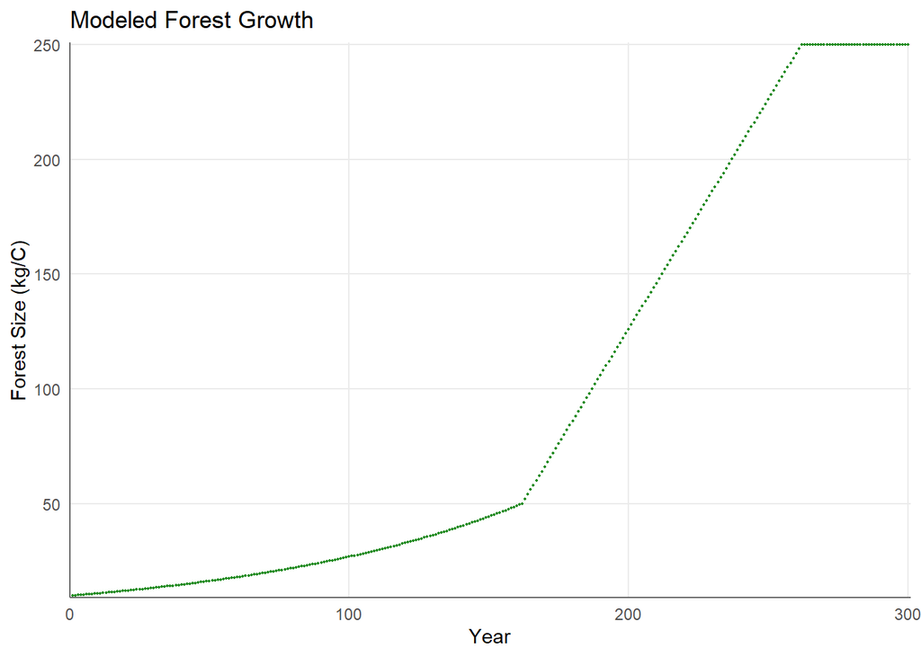

```r
#graph the Results
ggplot(as.data.frame(forest_300_result), aes(year, size))+
  geom_point(colour = "forestgreen", size = .3) +
  labs(title = "Modeled Forest Growth", x = "Year", y = "Forest Size (kg/C)")+
  theme_minimal() +
  theme(axis.line = element_line(color = "dimgrey"),
        panel.border = element_rect(fill = NA, color = NA),
        panel.grid.minor.y = element_blank(),
        panel.grid.minor.x = element_blank()) +
  scale_x_continuous(expand = c(0.0,1)) +
  scale_y_continuous(expand = c(0.0,1))
```

### Sobel Sensitivity

Assume that they are all normally distributed with means as given above and standard deviation of 10% of mean value

```r
#initial population value
Pinitial=10

#remembering the initial parameters
#forest_parms = list(K=250, r = 0.01, g = 2, Ct = 50)

#first set the number of parameters
np=100
K = rnorm(mean=250, sd=25, n=np)
r = rnorm(mean=0.01, sd=0.001, n=np)
g = rnorm(mean=2, sd=0.2, n=np)
X1 = cbind.data.frame(r=r, K=K, g=g, Ct=50)

#second set of samples
K = rnorm(mean=250, sd=25, n=np)
r = rnorm(mean=0.01, sd=0.001, n=np)
g = rnorm(mean=2, sd=0.2, n=np)
X2 = cbind.data.frame(r=r, K=K, g=g, Ct=50)

#create sobel object that holds the 2 sample datasets
sens_parms = soboljansen(model = NULL, X1, X2, nboot = 300)

#checking out the first values
head(sens_parms$X)
```

```
##             r        K        g Ct
## 1 0.008733057 206.8779 1.913093 50
## 2 0.009789478 264.2043 2.028849 50
## 3 0.009600336 225.0541 1.631354 50
## 4 0.009723516 247.1023 2.370017 50
## 5 0.010880655 261.5381 1.937498 50
## 6 0.009221630 259.3108 2.191648 50
```

```r
# gets results for each year for 300 years
times = seq(from=1, to=300) #number of simulations runs
parms = list(r=sens_parms$X$r[1], K=sens_parms$X$K[1], g=sens_parms$X$g[1], Ct=sens_parms$X$Ct[1]) #first set of parameters
forest_result = ode(y=Pinitial, times=times, func=forest_growth, parms=parms) #run ODE to get results for first set

#checking out first values
head(forest_result)
```

```
##      time        1
## [1,]    1 10.00000
## [2,]    2 10.08771
## [3,]    3 10.17620
## [4,]    4 10.26546
## [5,]    5 10.35550
## [6,]    6 10.44633
```

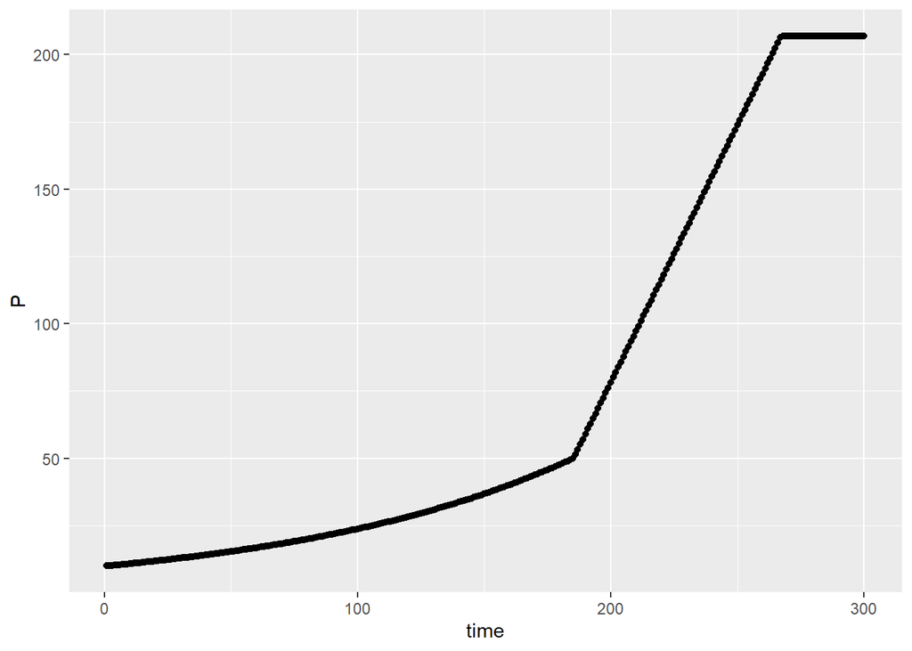

```r
colnames(forest_result)=c("time","P") #change column names so easier to use

#change to a dataframe to plot
forest_result = as.data.frame(forest_result)
ggplot(forest_result, aes(time, P))+
  geom_point()
```

```r
#this plot confirms our ODE results make sense so now we can begin running with the other parameters to see how sensitive our analysis is based on the parameters: g, K, and r
```

## Sensitivity Analysis of Maximum Forest Size

Graph the results of the sensitivity analysis as a box plot of maximum forest size and a plot of the two sobol indices (S and T)

```r
#max population from first set of parameters
max_pop = max(forest_result$P)
max_pop
```

```
## [1] 206.8779
```

```r
#how many years required to get to the maximum poputation
max_year = which.max(forest_result$P)
```

```r
#create a function to pull out max_year and max_pop
compute_max_metrics = function(forest_result) {
  max_pop = max(forest_result$P)
  idx = which.max(forest_result$P)
  max_year = forest_result$time[idx]
return(list(max_pop=max_pop, max_year=max_year))
}

#try it on our first parameter set
compute_max_metrics(forest_result)

#create a wrapper function that will solve and return the max_pop and max_year for each set of parameters created above
forest_wrapper = function(r, K, g, Ct, Pinitial, times, func) {
    parms = list(r=r, K=K, g=g, Ct=Ct) #list parameters needed
    forest_result = ode(y=Pinitial, times=times, func=forest_growth, parms=parms) #solve function
    colnames(forest_result)=c("time","P") #change column names
  max_metrics=compute_max_metrics(as.data.frame(forest_result)) #find max_pop and max_year
  return(max_metrics)
}

#use pmap tp return all results for all 100 sets of parameters
all_forest_results = sens_parms$X %>%
  pmap(forest_wrapper, Pinitial=Pinitial, times=times, func=forest_growth)

#use results from above (pmap) and turn into nice dataframe
all_forest_results_df = all_forest_results %>% map_dfr(`[`,c("max_pop","max_year"))


#turn into tidy format
final_forest = all_forest_results_df %>%
  gather(key="metric", value="value")
```

[output not shown]

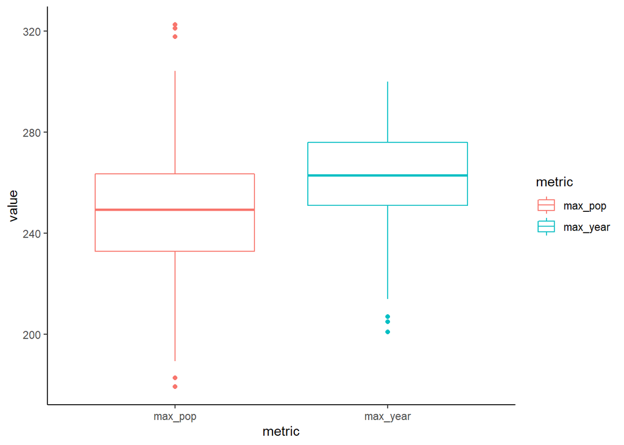

```r
#plot it!
ggplot(final_forest, aes(metric, value, col=metric))+
  geom_boxplot()+
  theme_classic()
```

Looking at the sensitivity for each parameter on `max_pop`

```r
sens_parms_max_pop = sensitivity::tell(sens_parms,all_forest_results_df$max_pop)
#first-order indices(S)
sens_parms_max_pop$S
```

```
##      original         bias std. error  min. c.i. max. c.i.
## r  0.11955611 -0.024282435 0.16002476 -0.1081930 0.5129641
## K  0.81751048 -0.002847984 0.08806252  0.6614480 1.0040408
## g  0.04864116 -0.026012253 0.15366955 -0.1620310 0.4329986
## Ct 0.02228832 -0.026198244 0.15383916 -0.2083836 0.4119011
```

```r
#total sensitivity index (T)
sens_parms_max_pop$T
```

```
##      original        bias std. error    min. c.i. max. c.i.
## r  0.13608012 0.003165912 0.05254261  0.019806854 0.2231652
## K  0.75914843 0.021404851 0.14679517  0.379126541 0.9686139
## g  0.03034359 0.000912677 0.01373853 -0.004452155 0.0509415
## Ct 0.00000000 0.000000000 0.00000000  0.000000000 0.0000000
```

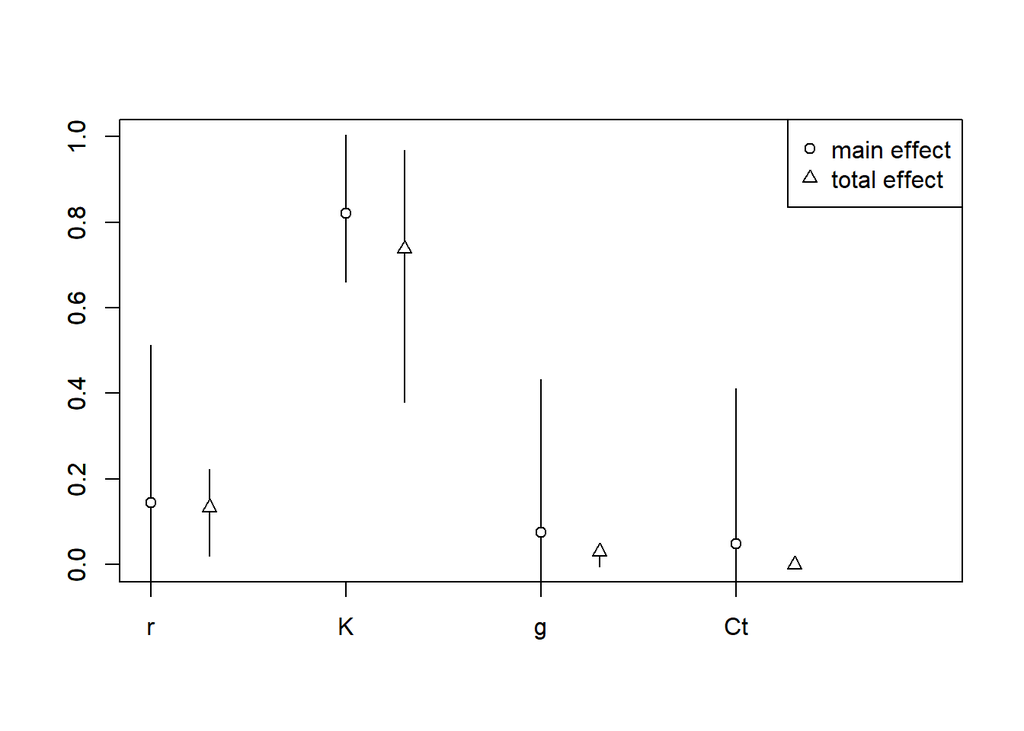

```r
#plot to see the difference
plot(sens_parms_max_pop)
```

Looking at the sensitivity for each parameter on `max_year`

```r
sens_parms_max_year = sensitivity::tell(sens_parms,all_forest_results_df$max_year)
#first-order indices (S)
sens_parms_max_year$S
```

```
##        original        bias std. error   min. c.i. max. c.i.
## r   0.516783271 -0.01059072  0.1055656  0.35497706 0.7812104
## K   0.166629875 -0.01916922  0.1371409 -0.06078588 0.5145601
## g   0.002964847 -0.02195185  0.1505868 -0.24453546 0.3666247
## Ct -0.108060050 -0.02160204  0.1713403 -0.39680748 0.2985790
```

```r
#total sensitivity index (T)
sens_parms_max_year$T
```

```
##     original       bias std. error  min. c.i. max. c.i.
## r  0.7482625 0.01826682 0.14053287 0.40714715 0.9764206
## K  0.2900153 0.01039379 0.06720858 0.12865807 0.3974147
## g  0.1676047 0.00762410 0.03719081 0.07329638 0.2188124
## Ct 0.0000000 0.00000000 0.00000000 0.00000000 0.0000000
```

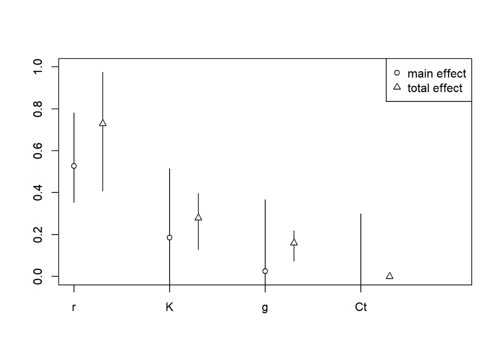

```r
#plot to see the difference
plot(sens_parms_max_year)
```